# Chapter 09 - Judging Model Effectiveness

```r
here::i_am(fs::path("tidy-modeling-with-r", "chapter-09.qmd"))
```

```
here() starts at /home/alex/r-projects/brush-up
```

```r
library(here)
source(here("tidy-modeling-with-r", "setup.R"))
```

okay so now we have a model. now what - let’s see how it stacks up. no bs - let’s use empirical evidence. no using data used to create the model we’re stick with out small test subset and only using it *once*.

lots of theory in this chapter. showcasing how important it is in choosing your metrics. the authors showed two common metrics for regression models root mean squared error (RMSE) and coefficient of determination (r^2). they loot similiar when ploted but the former is a measure of accuracy, while the latter measures correlation.

the author goes into a big example to sort of drive the look at the big picture point home.

## regression metrics

we’re going to use the `yardstick` package and it has a consistent function format

`function(data, truth, ...)`

truth is the col with the observed outcome value

we’re going to use the data we have as an example.

> we *will* be using test data at this point however, in normal use do **not** do this at this point under normal circumstances

```r
ames_test_res <- predict(lm_fit, new_data = select(ames_test, -Sale_Price))
ames_test_res
```

```
# A tibble: 588 × 1
   .pred
   <dbl>
 1  5.07
 2  5.31
 3  5.28
 4  5.33
 5  5.30
 6  5.24
 7  5.67
 8  5.52
 9  5.34
10  5.00
# ℹ 578 more rows
```

let match the preds with the observed

```r
ames_test_res <-
  bind_cols(
    ames_test_res,
    select(ames_test, Sale_Price)
  )
ames_test_res
```

```
# A tibble: 588 × 2
   .pred Sale_Price
   <dbl>      <dbl>
 1  5.07       5.02
 2  5.31       5.39
 3  5.28       5.28
 4  5.33       5.28
 5  5.30       5.28
 6  5.24       5.26
 7  5.67       5.73
 8  5.52       5.60
 9  5.34       5.32
10  5.00       4.98
# ℹ 578 more rows
```

you’ll notice everything is still log10 scale. which is good it’s best to compare with both values using the same scale.

lets plot before we even consider the standard metrics

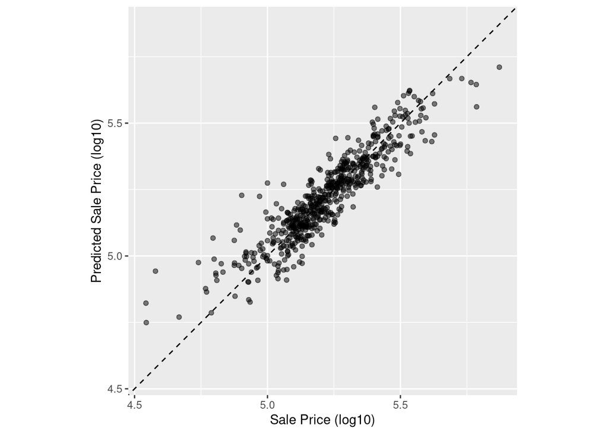

```r
ggplot(ames_test_res, aes(x = Sale_Price, y = .pred)) +
  # Create a diagonal line:
  geom_abline(lty = 2) + # lty for lintetype, for dotted line
  geom_point(alpha = 0.5) +
  labs(y = "Predicted Sale Price (log10)", x = "Sale Price (log10)") +
  # Scale and size the x- and y-axis uniformly:
  coord_obs_pred()
```

i dunno if they go over vetiver or pins or anything in this. however the author notes that the tail ends of the model don’t quite predict as well. and I was just thinking how that would be great doco for the model with the model card. like hey this model is great for the middle but performs poorly at these cutoffs etc…

alrighty, now lets compute some metrics…

```r
# rmse

rmse(ames_test_res, truth = Sale_Price, estimate = .pred)
```

```
# A tibble: 1 × 3
  .metric .estimator .estimate
  <chr>   <chr>          <dbl>
1 rmse    standard      0.0736
```

that was easy enough.

author makes note of the `"standard"` in the estimator column. and notes that there are others types as well.

cool, you can create a whole metric set.

I can see where this is all headed - create whole model factories. just shoot data through a ton of predefined models and recipes and have your metrics all picked out. good stuff.

```r
ames_metrics <- metric_set(rmse, rsq, mae)

ames_metrics(ames_test_res, truth = Sale_Price, estimate = .pred)
```

```
# A tibble: 3 × 3
  .metric .estimator .estimate
  <chr>   <chr>          <dbl>
1 rmse    standard      0.0736
2 rsq     standard      0.836
3 mae     standard      0.0549
```

authors state that yardstick doesnt include adjusted *R*^2 because it uses the same to fit the model as it does to evaluate the model. and its always better to keep separate/ better metrics available.

## binary classification metrics

```r
data(two_class_example)
tibble(two_class_example)
```

```
# A tibble: 500 × 4
   truth   Class1   Class2 predicted
   <fct>    <dbl>    <dbl> <fct>
 1 Class2 0.00359 0.996    Class2
 2 Class1 0.679   0.321    Class1
 3 Class2 0.111   0.889    Class2
 4 Class1 0.735   0.265    Class1
 5 Class2 0.0162  0.984    Class2
 6 Class1 0.999   0.000725 Class1
 7 Class1 0.999   0.000799 Class1
 8 Class1 0.812   0.188    Class1
 9 Class2 0.457   0.543    Class2
10 Class2 0.0976  0.902    Class2
# ℹ 490 more rows
```

example^ class1 and class2 are class predictions predicted is the ahrd prediction

yardstick has a *nice* suite of tools for these kinds of things

```r
# A confusion matrix:
conf_mat(two_class_example, truth = truth, estimate = predicted)
```

```
          Truth
Prediction Class1 Class2
    Class1    227     50
    Class2     31    192
```

```
#>           Truth
#> Prediction Class1 Class2
#>     Class1    227     50
#>     Class2     31    192
```

```r
# Accuracy:
accuracy(two_class_example, truth, predicted)
```

```
# A tibble: 1 × 3
  .metric  .estimator .estimate
  <chr>    <chr>          <dbl>
1 accuracy binary         0.838
```

```
#> # A tibble: 1 × 3
#>   .metric  .estimator .estimate
#>   <chr>    <chr>          <dbl>
#> 1 accuracy binary         0.838
```

```r
# Matthews correlation coefficient:
mcc(two_class_example, truth, predicted)
```

```
# A tibble: 1 × 3
  .metric .estimator .estimate
  <chr>   <chr>          <dbl>
1 mcc     binary         0.677
```

```
#> # A tibble: 1 × 3
#>   .metric .estimator .estimate
#>   <chr>   <chr>          <dbl>
#> 1 mcc     binary         0.677
```

```r
# F1 metric:
f_meas(two_class_example, truth, predicted)
```

```
# A tibble: 1 × 3
  .metric .estimator .estimate
  <chr>   <chr>          <dbl>
1 f_meas  binary         0.849
```

```
#> # A tibble: 1 × 3
#>   .metric .estimator .estimate
#>   <chr>   <chr>          <dbl>
#> 1 f_meas  binary         0.849
```

```r
# Combining these three classification metrics together
classification_metrics <- metric_set(accuracy, mcc, f_meas)
classification_metrics(two_class_example, truth = truth, estimate = predicted)
```

```
# A tibble: 3 × 3
  .metric  .estimator .estimate
  <chr>    <chr>          <dbl>
1 accuracy binary         0.838
2 mcc      binary         0.677
3 f_meas   binary         0.849
```

```
#> # A tibble: 3 × 3
#>   .metric  .estimator .estimate
#>   <chr>    <chr>          <dbl>
#> 1 accuracy binary         0.838
#> 2 mcc      binary         0.677
#> 3 f_meas   binary         0.849
```

that is slick. keep what you want, and nothing else.

auc and roc

```r
two_class_curve <- roc_curve(two_class_example, truth, Class1)
two_class_curve
```

```
# A tibble: 502 × 3
   .threshold specificity sensitivity
        <dbl>       <dbl>       <dbl>
 1 -Inf           0                 1
 2    1.79e-7     0                 1
 3    4.50e-6     0.00413           1
 4    5.81e-6     0.00826           1
 5    5.92e-6     0.0124            1
 6    1.22e-5     0.0165            1
 7    1.40e-5     0.0207            1
 8    1.43e-5     0.0248            1
 9    2.38e-5     0.0289            1
10    3.30e-5     0.0331            1
# ℹ 492 more rows
```

```
#> # A tibble: 502 × 3
#>   .threshold specificity sensitivity
#>        <dbl>       <dbl>       <dbl>
#> 1 -Inf           0                 1
#> 2    1.79e-7     0                 1
#> 3    4.50e-6     0.00413           1
#> 4    5.81e-6     0.00826           1
#> 5    5.92e-6     0.0124            1
#> 6    1.22e-5     0.0165            1
#> # ℹ 496 more rows
```

```r
roc_auc(two_class_example, truth, Class1)
```

```
# A tibble: 1 × 3
  .metric .estimator .estimate
  <chr>   <chr>          <dbl>
1 roc_auc binary         0.939
```

```
#> # A tibble: 1 × 3
#>   .metric .estimator .estimate
#>   <chr>   <chr>          <dbl>
#> 1 roc_auc binary         0.939
```

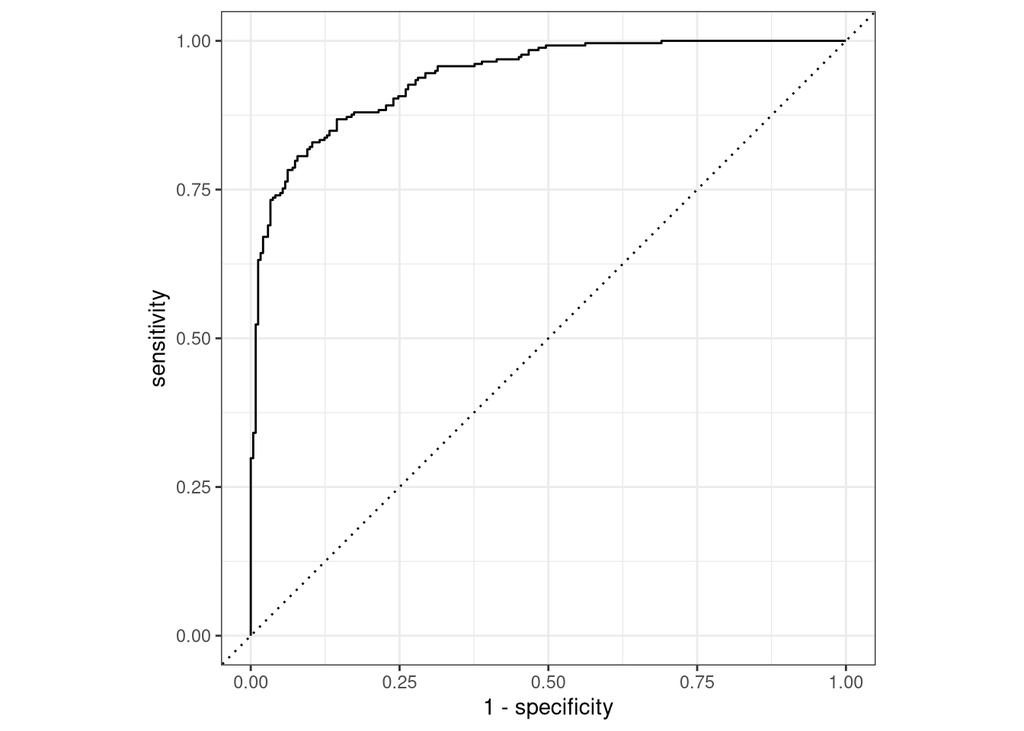

```r
autoplot(two_class_curve)
```

what about more than 2 classes?

```r
data(hpc_cv)
tibble(hpc_cv)
```

```
# A tibble: 3,467 × 7
   obs   pred     VF      F       M          L Resample
   <fct> <fct> <dbl>  <dbl>   <dbl>      <dbl> <chr>
 1 VF    VF    0.914 0.0779 0.00848 0.0000199  Fold01
 2 VF    VF    0.938 0.0571 0.00482 0.0000101  Fold01
 3 VF    VF    0.947 0.0495 0.00316 0.00000500 Fold01
 4 VF    VF    0.929 0.0653 0.00579 0.0000156  Fold01
 5 VF    VF    0.942 0.0543 0.00381 0.00000729 Fold01
 6 VF    VF    0.951 0.0462 0.00272 0.00000384 Fold01
 7 VF    VF    0.914 0.0782 0.00767 0.0000354  Fold01
 8 VF    VF    0.918 0.0744 0.00726 0.0000157  Fold01
 9 VF    VF    0.843 0.128  0.0296  0.000192   Fold01
10 VF    VF    0.920 0.0728 0.00703 0.0000147  Fold01
# ℹ 3,457 more rows
```

so even with multi classes everything is basically the same:

```r
accuracy(hpc_cv, obs, pred)
```

```
# A tibble: 1 × 3
  .metric  .estimator .estimate
  <chr>    <chr>          <dbl>
1 accuracy multiclass     0.709
```

```
#> # A tibble: 1 × 3
#>   .metric  .estimator .estimate
#>   <chr>    <chr>          <dbl>
#> 1 accuracy multiclass     0.709
```

```r
mcc(hpc_cv, obs, pred)
```

```
# A tibble: 1 × 3
  .metric .estimator .estimate
  <chr>   <chr>          <dbl>
1 mcc     multiclass     0.515
```

```
#> # A tibble: 1 × 3
#>   .metric .estimator .estimate
#>   <chr>   <chr>          <dbl>
#> 1 mcc     multiclass     0.515
```

however .estimator changes.